# d586-rnn-miniproject2

## Data 586 Miniproject 2 - RNN

## Home Energy Use Prediction

## 2020-04-26

### 1. Dataset

Stephen Makonin, “HUE: The Hourly Usage of Energy Dataset for Buildings in British Columbia,” Data in Brief, vol. 23, no. 103744, pp. 1-4 (2019).

https://dataverse.harvard.edu/dataset.xhtml?persistentId=doi:10.7910/DVN/N3HGRN

### 2. About

I am trying to predict home energy use based on previous energy use. My inputs are:

- Hourly Energy Use (kW hrs)
- Month value (1-12)/12
- Type of home (integer value 1-6)

I decided on a time window of 168 hours previous to the time of interest (look back one week and include all of those values with the current observation).

1) I initially created this model using only one house's data. This worked well and I could get a MSE of 0.34 on the test data with very reasonable-looking predictions.

2) Then I expanded my input data to include all 16 houses in the dataset that had less than 1% of their records missing and were in the same city (Vancouver). The list of these houses is at the bottom of this cell. I used panda's interpolation function to impute the missing data and combined all the data into one large training set (~10x more observations than the original single house's dataset). I also switched to Mean Absolute Error as I reasoned that with a larger dataset I would have more outliers and MAE should be more robust to that than MSE.

The model is an RNN with LSTM and I am training on the first 70% of the data from each home (combined) and validating on the remaining 30% from each home (combined).

I am using the following houses (the format of the table is not ideal when rendered to markdown):

House | FirstReading |LastReading| Cover| HouseType|

*1 2012-06-01 2015-10-03 1.000 bungalow (1* 2 2016-06-09 2019-01-07 0.993 duplex (2  
*4 2015-01-30 2018-01-29 0.995 character (3* 5 2015-01-30 2018-01-29 0.995 modern (4  
*6 2015-01-30 2018-01-29 0.997 apartment (5* 8 2015-02-21 2018-02-20 0.987 character (3  
*9 2015-05-01 2018-02-21 0.996 special (6* 10 2015-02-21 2018-02-20 0.995 special (6  
*11 2015-02-21 2018-02-20 0.990 duplex (2* 12 2015-02-21 2018-02-20 0.992 apartment (5  
*13 2015-02-21 2018-02-20 0.998 special (6* 14 2015-02-21 2018-02-20 0.995 modern (4  
*17 2016-06-01 2017-04-29 0.996 apartment (5* 19 2015-03-26 2018-03-25 0.993 special (6  
*20 2015-08-21 2018-04-20 0.998 character (3* 22 2016-06-29 2018-06-05 0.996 apartment (5

My starting point for this project was this tutorial so my notebook definitely has echos of the code provided: https://towardsdatascience.com/time-series-forecasting-with-lstms-using-tensorflow-2-and-keras-in-python-6ceee9c6c651

```python
import datetime


import tensorflow as tf
import numpy as np
import pandas as pd
from pylab import rcParams
import matplotlib.pyplot as plt
from matplotlib import rc

%matplotlib inline
%config InlineBackend.figure_format='retina'


rcParams['figure.figsize'] = 16, 10
```

## Load Data

The following cell imports all data of interest and preps it so each observation includes information on the previous n (168 hours in this case) hours of data as well as the month, and type of house. This also splits it into a training and test set.

This takes a long time to run but if the houselist and housetype lists are reduced to only a few entries it will run much faster.

```python
#homes of interest
#Reduce this down to just a single entry per list if you don't want to load all of this data!
houselist = [1,2,4,5,6,8,9,10,11,12,13,14,17,19,20,22]
housetype = [1,2,3,4,5,3,6,6,2,5,6,4,5,6,3,5]


#Define functions to load files, process, and append to training and test data in a way that avoids
# accidentally including two house's data in 168 hour lookback for an observation.

def get_df(houselist,housetype,n):
    print("House Num",houselist[n])
    fname = "data/Residential_"+str(houselist[n])+".csv"
    singleDF = pd.read_csv(fname)
    singleDF["date"]=pd.to_datetime(singleDF["date"])
    singleDF["tstamp"]=singleDF.apply(lambda x: x.date+pd.Timedelta(hours=x.hour), axis=1)
    singleDF.drop(["date","hour"], axis=1, inplace=True)
    singleDF.set_index(["tstamp"], inplace=True)
    print("Using linear interpolation to impute data for",len(singleDF[singleDF["energy_kWh"].isna()]),"records")
    singleDF = singleDF.assign(energy_kWh=singleDF["energy_kWh"].interpolate(method="linear"))
    print("Resulting Missing Data Count:",len(singleDF[singleDF["energy_kWh"].isna()]))
    singleDF["houseType"]=housetype[n]
    return(singleDF)

def split_data(df, split_percent=0.7):
    n = len(df)
    tt_split = int(n * split_percent)
    #splitTest = n - rangeTrain

    train_data = df.iloc[0:tt_split]
    test_data = df.iloc[tt_split:n]
    print(n, "records total")
    print("Training Set: ",len(train_data), "\nTest Set: ",len(test_data))
    return (train_data,test_data)

def create_timewindows(df, response_series, steps=1):
    pred_list1 = []
    pred_list2 = []
    pred_list3 = []
    response_list = []
    for i in range(len(df) - steps):
        pred_list1.append(df.iloc[i:(i + steps)].values)
        pred_list2.append(df.iloc[i:(i + steps)].index.month.values/12.0)
        response_list.append(response_series.iloc[i +steps])

    pred_array1 = np.array(pred_list1)
    pred_array2 = np.array(pred_list2)
    pred_array2 = np.reshape(pred_array2,(pred_array2.shape[0],pred_array2.shape[1],1))
    #print(pred_array1.shape)
    #print(pred_array2.shape)
    pred_concat = np.concatenate((pred_array1,pred_array2),axis=2)
    print(pred_concat.shape)
    return pred_concat, np.reshape(np.array(response_list),(len(response_list),1))
#########################
## Drive the functions

num_steps=168 #look back this many hours

train_list = []
test_list = []

for n in range(0,len(houselist)):
    tempdf = get_df(houselist,housetype,n)
    tr,te = split_data(tempdf)
    xtr, ytr = create_timewindows(tr, tr["energy_kWh"], num_steps)
    xte, yte = create_timewindows(te, te["energy_kWh"], num_steps)

    if n == 0:
        x_train_data=xtr
        y_train_data=ytr
        x_test_data=xte
        y_test_data=yte
    else:
        x_train_data=np.concatenate((x_train_data,xtr),axis=0)
        y_train_data=np.concatenate((y_train_data,ytr),axis=0)
        x_test_data=np.concatenate((x_test_data,xte),axis=0)
        y_test_data=np.concatenate((y_test_data,yte),axis=0)
```

### About the Model

I started with a simple model and added depth and more units until the training stopped working (i.e. could not reduce loss and just settled on predicting the mean of all energy use as the output). Using the adam optimizer with default learning rate gave good results and fiddling with the learning rate did not improve the performance.

```python
#Build NN
initial_units = 256
tsmod = tf.keras.Sequential()
tsmod.add(tf.keras.layers.LSTM(units=initial_units,return_sequences=True,input_shape=(x_train_data.shape[1], x_train_data.shape[2])))
tsmod.add(tf.keras.layers.LSTM(units=int(initial_units/2),return_sequences=True))
tsmod.add(tf.keras.layers.LSTM(units=int(initial_units/8)))
tsmod.add(tf.keras.layers.Dense(units=1))

#Compile NN

tsmod.compile(loss='mean_absolute_error', optimizer="adam")
tsmod.summary()
```

```
Model: "sequential_2"
_________________________________________________________________
Layer (type)                 Output Shape              Param #
=================================================================
lstm_7 (LSTM)                (None, 168, 256)          266240
_________________________________________________________________
lstm_8 (LSTM)                (None, 168, 128)          197120
_________________________________________________________________
lstm_9 (LSTM)                (None, 32)                20608
_________________________________________________________________
dense_2 (Dense)              (None, 1)                 33
=================================================================
Total params: 484,001
Trainable params: 484,001
Non-trainable params: 0
_________________________________________________________________
```

## Model - Load or Save Weights/Model

(Uncomment portions as desired)

```python
#Save Functions
#tsmod.save_weights("168stepadam-001.h5")
#tf.keras.models.save_model(tsmod, "saved_rnn")

#Load Functions
#tsmod.load_weights("168stepadam-001.h5")
#tsmod = tf.keras.models.load_model("saved_rnn")
```

## Model - Train

Note that shuffle is intentional set to false as this is an LSTM and the order of the data it is fed matters. This likely makes for odd effects where the training data set transitions from one house's data to another, but presumably having the house type included as a variable helps take care of any issues around this.

```python
#Don't have validation data included, just to speed to training.
#validation_data=(x_test_data,y_test_data)

tsmod.fit(x_train_data, y_train_data, epochs=10,batch_size=2048, shuffle=False, verbose=1)
```

```
Train on 268841 samples
```

```
<tensorflow.python.keras.callbacks.History at 0x2416bb74d48>
```

## Results - Predict on entire test set

```python
#Validate NN
res = tsmod.predict(x_test_data)
#print(x_test_data.shape)
#print(res.shape)
y_test_data=y_test_data.reshape((len(y_test_data),1))
mse_res = (res - y_test_data)**2
print("MSE for test data:",mse_res.sum()/len(mse_res))
print("Actual Energy Use in kilowatts:",sum(y_test_data))
print("Predicted Energy Use in kilowatts:",sum(res))
print("Prediction as percentage of actual:",sum(res)/sum(y_test_data)*100)
```

```
MSE for test data: 0.2304195556270178
Actual Energy Use in kilowatts: [93532.627]
Predicted Energy Use in kilowatts: [79152.086]
Prediction as percentage of actual: [84.62510728]
```

## Results - Visualize and cacluate energy use for one week of test data

The full dataset is too large to see anything meaningful in a plot, so instead just focusing on one week. A different week can be chosen by changing the id_start value to a different index in the test dataset.

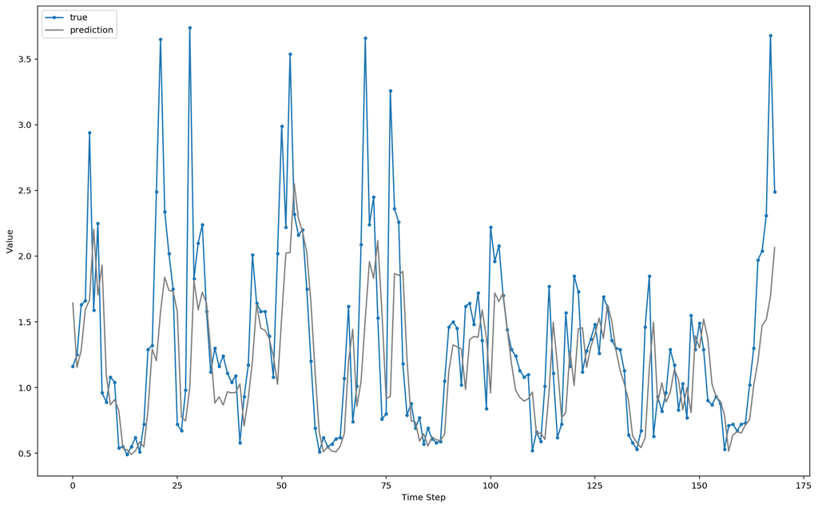

```
Actual Energy Use in kilowatts: [227.77]
Predicted Energy Use in kilowatts: [198.20398]
Prediction as percentage of actual: [87.01935263]
```

```python
id_start = 20200 #pick a start point in the test data
id_end = id_start+169

plt.plot(y_test_data[id_start:id_end], marker='.', label="true")
plt.plot(res[id_start:id_end], 'grey', label="prediction")
plt.ylabel('Value')
plt.xlabel('Time Step')
plt.legend()
plt.show()
actual_eng =sum(y_test_data[id_start:id_end])
predict_eng =sum(res[id_start:id_end])
percentage = predict_eng/actual_eng*100
print("Actual Energy Use in kilowatts:",actual_eng)
print("Predicted Energy Use in kilowatts:",predict_eng)
print("Prediction as percentage of actual:",percentage)
```

## Results - Discussion

Possible Future Work:

- More training time!
- Try to get tensorboard to work (was not writing data when I tried it)
- Investigate dilated cnns and sequence to sequence lstm rnns.

Main takeaways:

- LSTM RNN's are surprisingly accurate on time series data and seem to require less initial investigation than ARIMA, no need try to estimate and remove seasonality, etc. This seems like a very useful tool to have available when prediction accuracy is the goal.
- I wish I had known about Neural Networks and how to build these models at my previous job when I was involved in forecasting mining equipment fuel consumption, it would have been a useful type of model to include in the process.